# Maladie à Virus Ebola — Situation Report

Democratic Republic of Congo

Published

26 May 2026

## Introduction

The Democratic Republic of Congo is experiencing an outbreak of Maladie à Virus Ebola (MVE) with cases reported across health zones in Ituri and Nord-Kivu provinces. This report summarises the epidemiological situation based on data extracted from official INSP DRC situation reports. It is generated automatically and reflects the most recent available data.

## Methods

### Data sources

Epidemiological data were obtained from eleven PDF situation reports published by the Institut National de Santé Publique (INSP) DRC during the 2026 MVE outbreak in Ituri and Nord-Kivu provinces. PDFs were downloaded automatically from the INSP DRC website (https://insp.cd/ebola/), with a manifest ensuring idempotent incremental updates. MD5 checksums confirmed that the downloaded PDFs are byte-for-byte identical to those archived in the Kraemer lab repository, establishing that both sources operate on the same documents. For cross-source validation, pre-harmonised long-format case-count data were obtained from the Kraemer lab repository, which represents independent manual extraction of the same INSP DRC situation reports.

### Automated PDF extraction

Each PDF was passed to the Anthropic Claude claude-sonnet-4-6 large language model via the Messages API as a base64-encoded document, enabling pixel-level reading without reliance on the text layer. A temperature of 0 was used to maximise reproducibility. The model returned a structured JSON object containing four tables. The new-cases and cumulative case-count tables each provide rows normalised to province, health zone, and counts of suspected, probable, and confirmed cases and deaths; validation checks discarded tables identified as alert-investigation summaries rather than case counts. Where available (SitReps 006 onwards), the patient movement table (*Mouvement des malades*, Tableau VI) was also extracted, providing zone-level counts of patients in bed at the start of the day, new admissions, total isolated, and cumulative admissions. In addition, the Points d’Entrée/Points de Contrôle (PoE/PoC) summary table was extracted, recording aggregate counts of travellers screened, contacts listed, and alerts raised per reporting period. A second API call produced a verbatim full-text transcription stored as an audit trail.

### Data harmonisation

Zone names were normalised to canonical spellings. Suspect and probable case counts were combined into a single unconfirmed category to accommodate inconsistent column usage across situation reports from different issuing bodies. Cumulative counts were constrained to be monotonically non-decreasing within each health zone, and where multiple documents covered the same zone and date the row with the highest unconfirmed count was retained.

### Statistical analysis

All analyses and visualisations were produced in R (version 4.5.1) using the `tidyverse` suite [@tidyverse], with figures produced using `ggplot2` [@ggplot2] and tables formatted with `flextable` [@flextable]. The report was rendered with Quarto. The extraction pipeline and this report were developed with the assistance of GitHub Copilot (Microsoft) and the Claude API (Anthropic, model: claude-sonnet-4-6).

## Results

### Cumulative epidemic curve

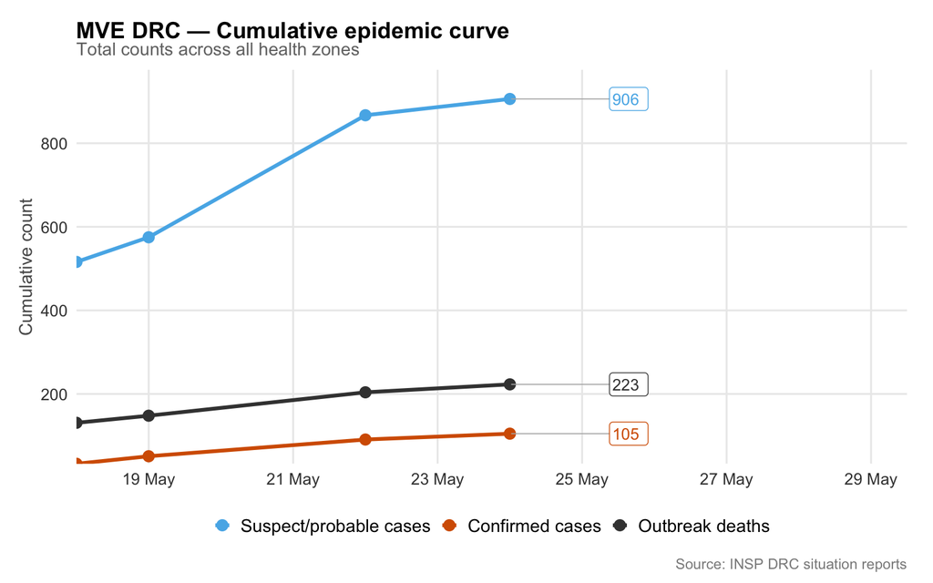

Figure 1: Cumulative MVE cases and deaths, DRC. Suspect and probable cases are combined. End-of-line labels show the latest recorded value. Source: INSP DRC.

### Daily new cases

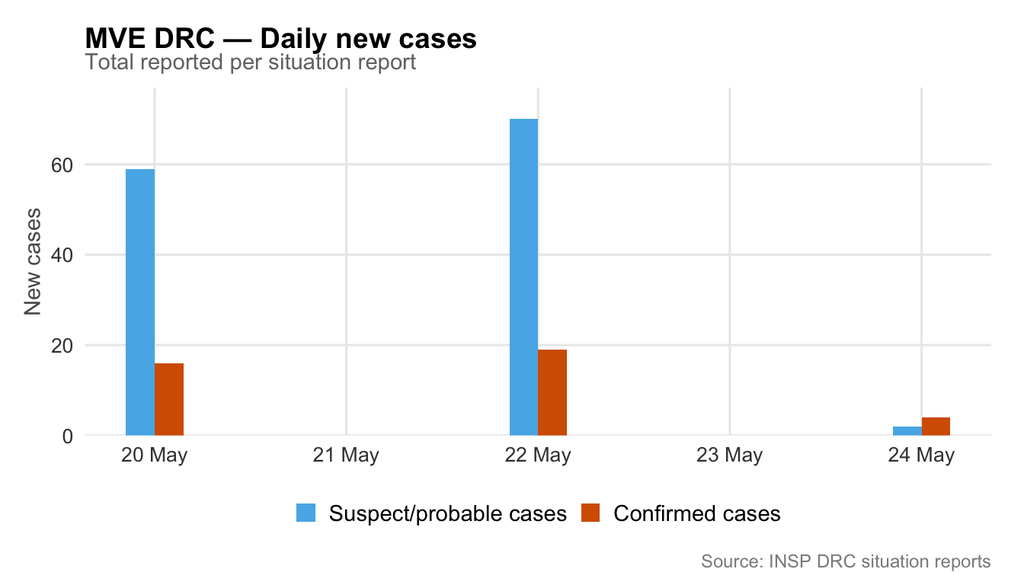

Figure 2: New cases reported per situation report across all health zones, DRC. Source: INSP DRC.

### Geographic distribution — cumulative counts

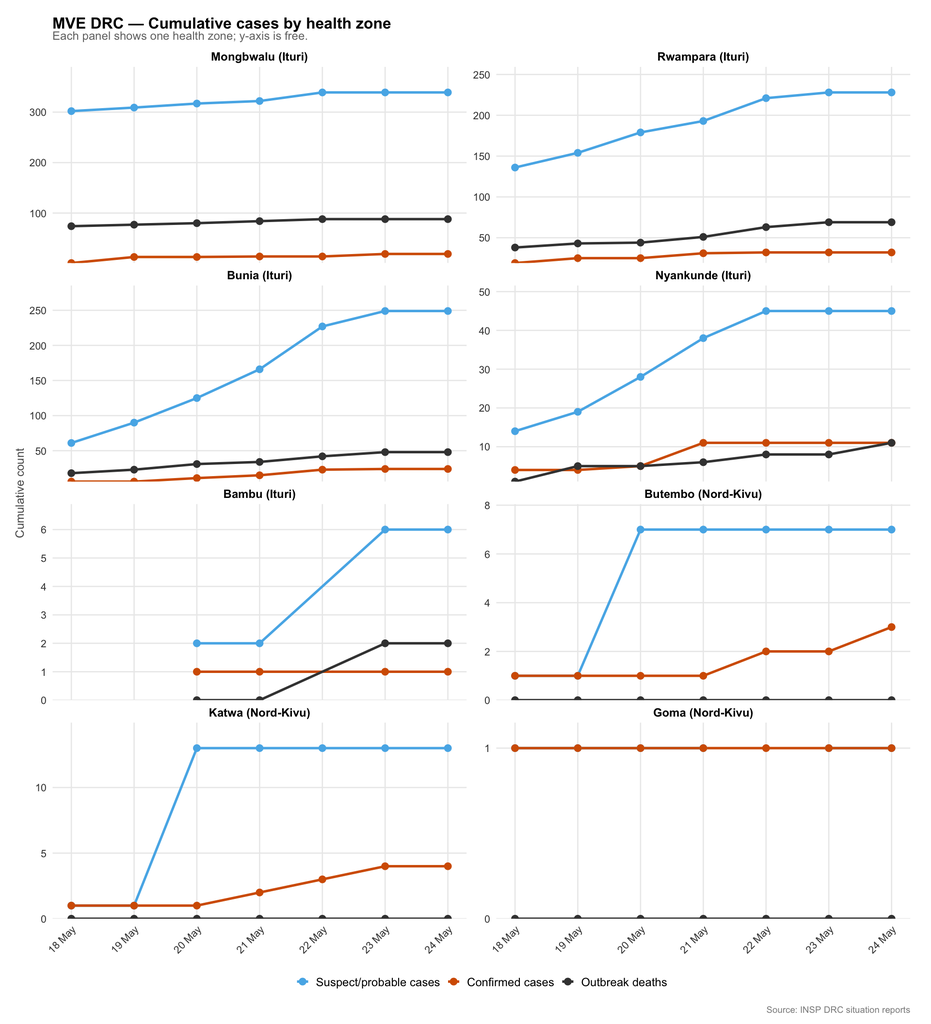

Figure 3: Cumulative cases by health zone. Y-axis is free across panels. Source: INSP DRC.

### Geographic distribution — new cases

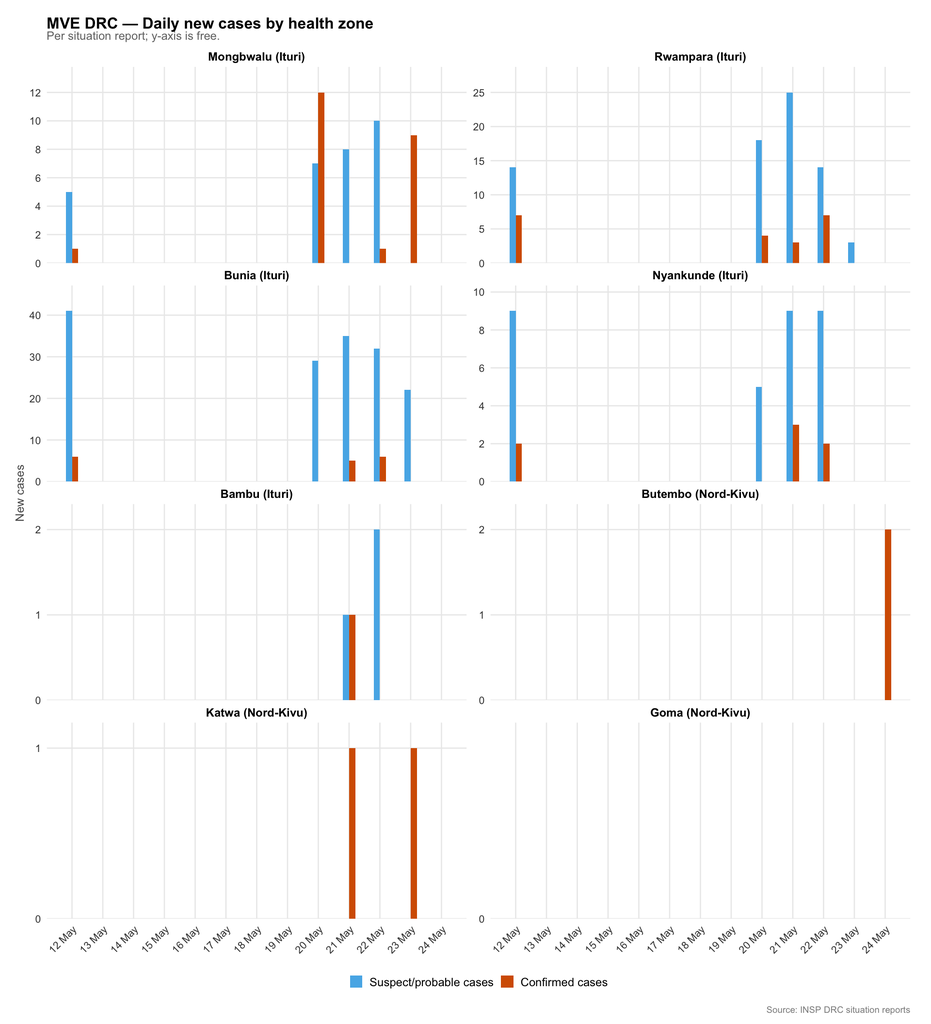

Figure 4: New cases per situation report by health zone. Y-axis is free across panels. Source: INSP DRC.

### Current counts by health zone

Table 1 presents the most recent cumulative case counts disaggregated by health zone, drawn from the latest available situation report for each zone.

Table 1: Table 1. Latest cumulative case counts by health zone.

| Health zone | Province | Latest sitrep | Suspect/probable | Confirmed | Deaths |
| --- | --- | --- | --- | --- | --- |
| Mongbwalu | Ituri | 24 May 2026 | 339 | 19 | 88 |
| Rwampara | Ituri | 24 May 2026 | 228 | 32 | 69 |
| Bunia | Ituri | 24 May 2026 | 249 | 24 | 48 |
| Nyankunde | Ituri | 24 May 2026 | 45 | 11 | 11 |
| Bambu | Ituri | 24 May 2026 | 6 | 1 | 2 |
| Butembo | Nord-Kivu | 24 May 2026 | 7 | 3 | 0 |
| Katwa | Nord-Kivu | 24 May 2026 | 13 | 4 | 0 |
| Goma | Nord-Kivu | 24 May 2026 | 1 | 1 | 0 |
| Total | — | 24 May 2026 | 888 | 95 | 218 |

### Cross-source validation

Cumulative zone-level counts from this pipeline are compared against the [Kraemer lab Ebola DRC 2026](https://github.com/kraemer-lab/Ebola_DRC_2026) repository, which codes INSP DRC situation reports into a standardised long-format by manual human extraction. Both pipelines operate on the same source PDFs (MD5-verified). Zone names differ between sources at two sites (Mongbwalu/Mongbalu and Nyankunde/Nyakunde); counts are matched on the harmonised name. `ND` values in the Kraemer lab series are treated as missing. Any divergence between the two series therefore reflects differences in extraction method — automated LLM-based visual extraction versus human manual coding — rather than differences in the source documents.

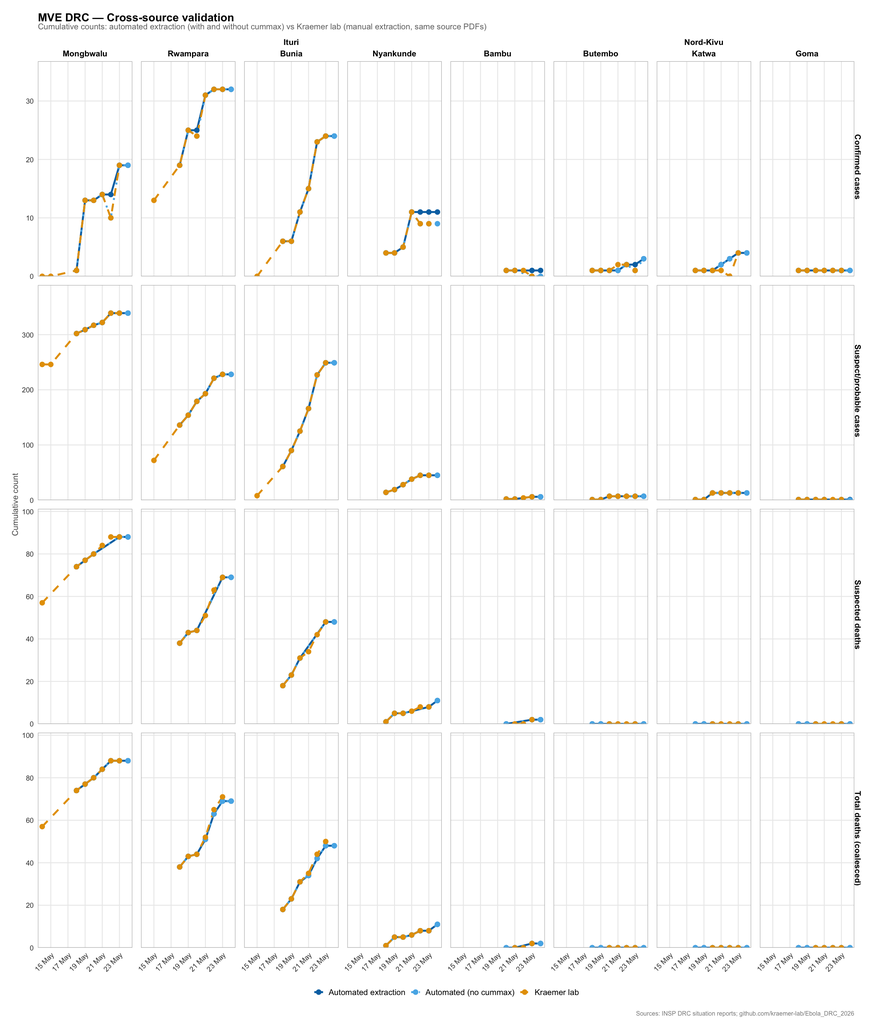

Figure 5: Cross-source comparison of cumulative confirmed cases, suspect/probable cases, and outbreak deaths by health zone. Solid lines: automated extraction (cummax applied); dotted lines: automated extraction (raw, no cummax); dashed lines: Kraemer lab (manual extraction). Both automated and Kraemer sources use identical PDFs; divergence reflects extraction method differences.

Table 2 presents numerical differences at the most recent date available in each source for each zone.

Table 2: Table 2. Cumulative case counts at the latest available date per zone: automated extraction vs Kraemer lab. Delta = ours minus Kraemer. Dashes indicate no data in that source.

| Health zone | Confirmed (ours) | Confirmed (Kraemer) | Δ confirmed | Suspect/prob. (ours) | Suspect/prob. (Kraemer) | Δ suspect/prob. | Deaths (ours) | Deaths (Kraemer) | Δ deaths |
| --- | --- | --- | --- | --- | --- | --- | --- | --- | --- |
| Bambu | 1 | 0 | 1 | 6 | 6 | 0 | 2 | 2 | 0 |
| Bunia | 24 | 24 | 0 | 249 | 249 | 0 | 48 | 50 | -2 |
| Butembo | 3 | 1 | 2 | 7 | 7 | 0 | 0 | 0 | 0 |
| Goma | 1 | 1 | 0 | 1 | 1 | 0 | 0 | 0 | 0 |
| Katwa | 4 | 4 | 0 | 13 | 13 | 0 | 0 | 0 | 0 |
| Mongbwalu | 19 | 19 | 0 | 339 | 339 | 0 | 88 | 88 | 0 |
| Nyankunde | 11 | 9 | 2 | 45 | 45 | 0 | 11 | 8 | 3 |
| Rwampara | 32 | 32 | 0 | 228 | 228 | 0 | 69 | 71 | -2 |

### Data quality notes — response indicators

Two discrepancies were identified through cross-source validation.

**Rwampara ambiguous table structure (21 May).** SitRep 007 presents Rwampara across three columns (in-bed: 21 | 15 | 35; total isolated: 23 | 19 | 46) whose relationship is not explained in the document — they may represent different isolation units, patient categories, or time sub-periods. The automated extraction summed the first two sub-rows (total isolated = 42); the Kraemer lab summed all three (88). Neither value can be verified against the source document. The 21 May Rwampara data point should be treated with caution in both series.

**New admissions column mapping (20–21 May).** SitReps 005 and 006 used an earlier table format that did not include an explicit “in-bed-previous-day” column. Kraemer’s extraction assigned the `new_all_admissions` label to what was in fact the in-bed-previous-day value for those two dates, with the consequence that their new-admissions series for 20–21 May reflects the wrong metric. Values from 22 May onwards, when the table format was standardised, are concordant between the two sources.

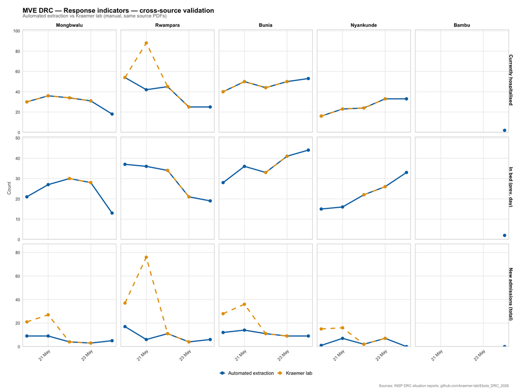

Figure 6: Cross-source comparison of zone-level response indicators. Solid lines: automated extraction; dashed lines: Kraemer lab. The 21 May Rwampara values are unreliable in both series: the sitrep presents three unexplained sub-columns whose relationship is ambiguous. For 20–21 May, Kraemer’s new-admissions values reflect a column-mapping error in the earlier table format.

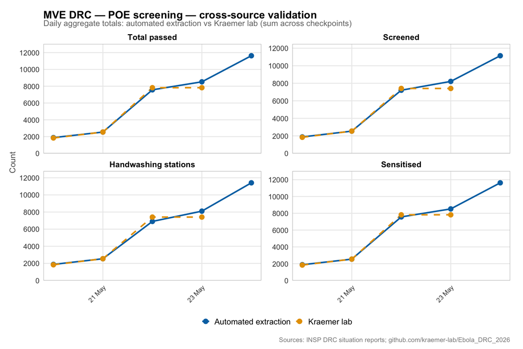

Figure 7: Cross-source comparison of daily Point of Entry (POE) screening totals. Automated extraction reports a single aggregate per sitrep date; Kraemer lab data are summed across individual checkpoints to produce a daily total.

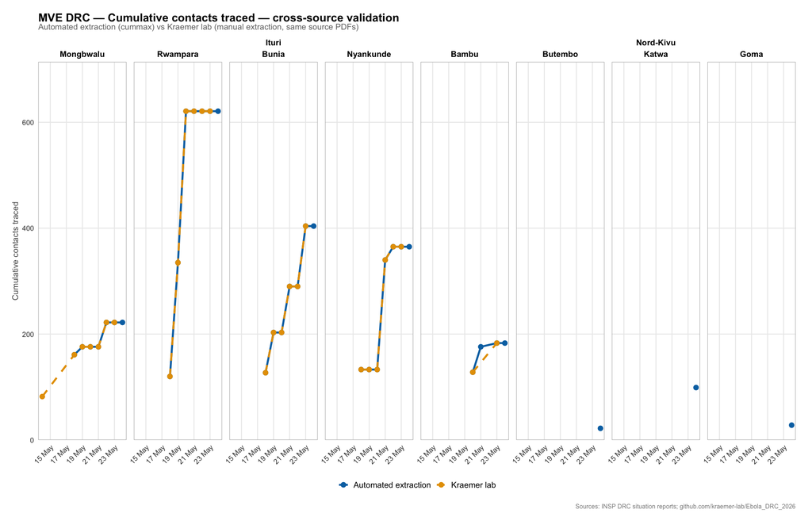

Figure 8: Cross-source comparison of cumulative contacts traced by health zone. Solid lines: automated extraction (cummax applied); dashed lines: Kraemer lab (manual extraction). ND values excluded.

## Discussion

The outbreak trajectory shows a consistent increase in suspect and probable case counts across the reporting period. Confirmed cases remain a minority of the total, reflecting the challenges of laboratory confirmation in the field setting. The geographic spread across both Ituri and Nord-Kivu provinces underscores the need for multi-province coordination of the response.

MD5 checksum verification confirmed that the PDFs processed by this pipeline are byte-for-byte identical to those archived in the Kraemer lab repository. Divergence in the cross-source comparison therefore reflects either differences in how each extraction method interprets ambiguous table layouts, or outright reading errors in one of the two series.